# act_report

## Report: act_report

### Introduction

Pour cette analyse, nous allons se poser les questions suivantes:

1. Quelles sont le nom des chiens les plus fréquents ?
2. Les photos des chiens qui ont une bonne note sont-ils retweeté et mis en favoris ?
3. Quelles sont les notes obtenues par `étape`

### 1. Le nom des chiens les plus fréquents

Le dataset que nous avons étudié possède une colonne **name** dans laquelle se trouve le nom des chiens pour chaque tweet. Il n'est pas possible pour nous de savoir si le nom d'une chien qui se repète dans le dataset soit une seule et même chien ou pas. Alors pour notre question actuelle, on ne prend pas en compte le fait que ce soit une même chien ou pas.

Pour pouvoir répondre à cette question, on a crée un **`Diagramme en Bar`** qui montre ne manière decroissante le nombre de chien pour chaque **nom**; comme l'indique la figure suivante:

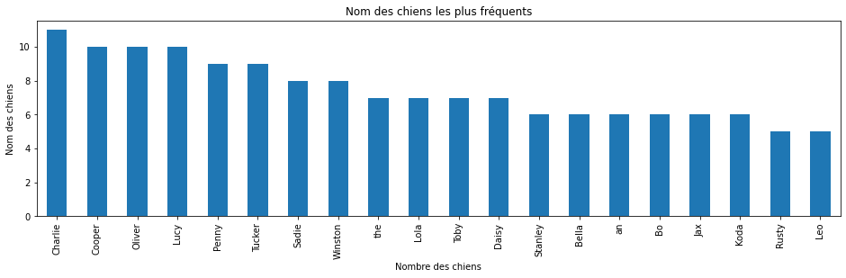

**Conclusion**: A partir de cette figure, on peut en conclure que **Charlie**, **Cooper**, **Oliver**, et **Lucy** sont les nom des chiens les plus célèbre sur les données que l'on étudie.

### 2. Relation note et J'aime-Partage

Il peut être intéressant de connaitre le fait que la note (**rating**) données aux chiens soit vraiement équitable. Une des indices qui nous permettent de connaitre celà c'est que le nombre de **J'aime** et de **partage** pour une photo soit supérieur à celle des autres photos si cette photo est bien noté.

Alors on a comparé la moyenne des **J'aime** et **Partage** des tweets les mieux notés avec les moins bien notés. Le resultat a validé l'hypothèse de début.

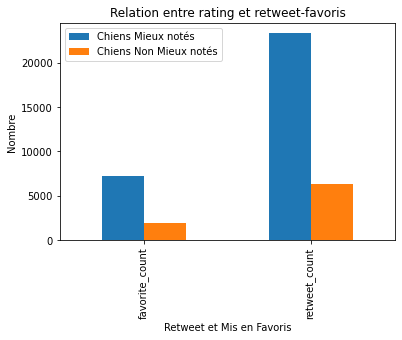

**Conclusion**: Le fait qu'il y a une grande différence entre les **J'aime** et **Partage** entre les tweets les mieux notées et les tweets les moins bien notées prouve que l'attribution des notes reflète bien la beauté de ces chiens, selon l'opinion publique.

### 3. Notes obtenus par étape de chien

L'étape est en quelque sorte l'age des chiens. Nous voulons savoir si il y a une rélation entre cette age et les note obtenu par chaque chien.

Pour faire cela, on doit tenir compte, le nombre des chiens par race, sinon l'étude ne serait pas équitable.

Le resultat obtenu est comme suit:

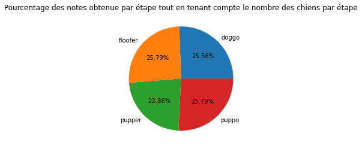

**Conclusion** : La note obtenue par les chiens n'est donc pas impacté par l'**étape**